# Random Forest

Bernard Asante

2024-09-23

# **Loading libraries**

```r
knitr::opts_chunk$set(echo = TRUE)
library(tidyverse)
library(tidymodels)
```

```r
library(sjPlot)
library(C50)
library(finalfit)
library(knitr)
library(gtsummary)
library(mlbench)
library(vip)
library(rsample)
library(rpart.plot)
library(tune)
library(recipes)
library(yardstick)
library(parsnip)
library(glmnet)
library(themis)
library(microbenchmark)
library(pROC)
```

# **Reading in data**

```r
data <- read_csv("mice_all_imp.csv")
```

## Converting variables to factor

```r
data <- data %>% mutate_at(3, factor)
data <- data %>% mutate_at(5:6, factor)
data <- data %>% mutate_at(8:12, factor)
data <- data %>% mutate_at(15:81, factor)
data <- data %>% mutate_at(83:93, factor)

data$ID <- NULL
data$ADM_STUDY_ID <- NULL
```

# **Exploratory Data Analysis on Outcome Variable**

Preparing diabetes variable. This will be used as an outcome variable.

From the data dictionary, DIS_DIAB_EVER DICTIONARY has 3 responses: 0 - “Never had diabetes” 1- “Ever had diabetes” 2 - “Presumed-Never had diabetes”

```r
table(data$DIS_DIAB_EVER) # This code displays the counts of the 0,1 and 2 responses in the DIS_DIAB_EVER variable
```

```
##
##     0     1     2
## 36714  3114  1359
```

## Recoding Predictor variable

```r
#From the can path dataset dictionary, 0 and 2 can be assumed to mean response for not having diabetes. I want to recode them into binary(dichotomous variable) where 0 and 2 will be recoded as "No" and 1 recoded as "Yes"

data <- data %>%
    mutate(diabetes = case_when(
        DIS_DIAB_EVER == 0 ~ "No",
        DIS_DIAB_EVER == 1 ~ "Yes",
        DIS_DIAB_EVER == 2 ~ "No")) %>%
        mutate(diabetes = as.factor(diabetes))
```

```r
data$DIS_DIAB_EVER <- NULL # I have to drop the main variable from the dataset
```

Both variables (DIS_DIAB_EVER and diabetes) convey essentially the same information. Including both can result in redundancy and multicollinearity. This redundancy can negatively impact model performance, interpretability, and variable significance measures.

## Checking levels

Here, i want to observe how the values of the outcome variable is arranged. From the dataset, which of the responses(“yes” and “No”) is set as a preference. That is when used in a table or graph(barplot), which response will come first.

```r
levels(data$diabetes)
```

```
## [1] "No"  "Yes"
```

I will have to factor the level to make “Yes” at level one or reference in logistic models and “No” at second level

## Summary statistics of diabetes variable

```r
data <- data %>%
  mutate(diabetes = factor(diabetes,
                           levels = c("Yes", "No"))) # This code reorders the factor levels of the diabetes variable, setting "Yes" as the reference level.
data$diabetes %>%
  summary()
```

```
##   Yes    No
##  3114 38073
```

From this code, we can see that “Yes” comes before “No” and that will be the arrangement in analysis and visualizations. For example when we plot a simple bar graph, the bar of “yes” will come before “No”.

Also, I can see imbalance in the outcome variable. Let us do further analysis to understand it properly. Here I will calculate the proportions of “Yes” and “No” responses.

## Calculating proportion of diabetes response

```r
prop_diabetes <- prop.table(table(data$diabetes)) * 100 # This line calculates the proportion (as percentages) of each level in the diabetes variable. It first creates a frequency table using table(), then converts it to proportions using prop.table(), and finally multiplies by 100 to express the values as percentages.

prop_diabetes
```

```
##
##       Yes        No
##  7.560638 92.439362
```

## Visualizing Diabetes response

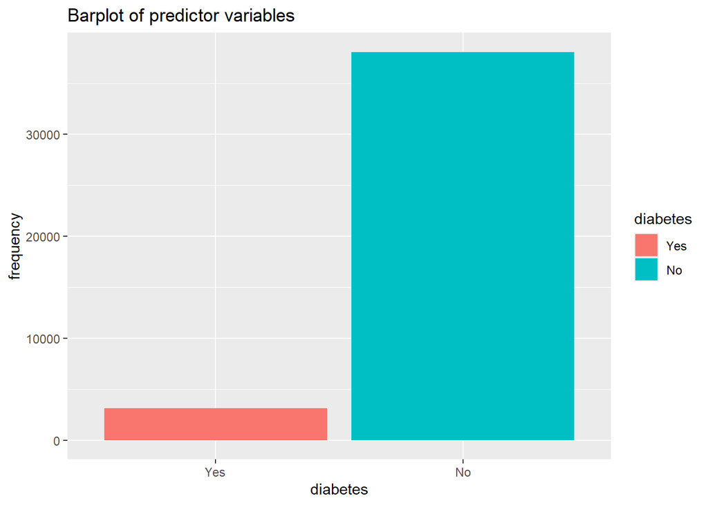

```r
data %>%
  count(diabetes) %>%
  ggplot(aes(x = diabetes, y = n, fill = diabetes))+
  geom_col()+
  labs(title = "Barplot of predictor variables",
       y = "frequency") #This code creates a bar plot to visualize the frequency of each category in the diabetes variable. It counts the number of observations for each diabetes category ("Yes" and "No"), and uses ggplot2 to display the results as colored bars
```

This plot above shows the level of imbalance in the outcome variable

# **Random Forest Model**

## Splitting the dataset

```r
set.seed(10)


data_split <- initial_split(data,
                            strata = diabetes,
                            prop = 0.80)#This code splits the dataset into training and testing subsets using an 80/20 ratio. The initial_split() function  ensures that the split is stratified by the diabetes variable—meaning the proportion of "Yes" and "No" cases is preserved in both subsets. The set.seed(10) ensures reproducibility of the split.
```

## Training and Testing Data

```r
train_data <- training(data_split) #This line extracts the training subset from the data_split object created earlier using initial_split(). The result, train_data, contains 80% of the original dataset, with class proportions of the diabetes variable preserved due to stratification.


test_data  <- testing(data_split) #This code extracts the testing subset from the data_split object, assigning it to test_data. It contains the remaining 20% of the data, also stratified by the diabetes variable to preserve class distribution.
```

## Detecting core

```r
cores <- parallel::detectCores()#This code detects the number of CPU cores available on the machine using the detectCores() function from the parallel package and stores that number in the cores variable.
cores
```

```
## [1] 8
```

## **Random forest model (Default hyperparameters)**

### Default RF model

This random model is build using default hyperparameters: min_n = NULL mtry = NULL

```r
rf_model_default <- rand_forest() %>%
  set_engine("ranger", num.threads = cores) %>%
  set_mode("classification")#This code initializes a Random Forest classification model using the ranger engine. It sets the number of processing threads to match the number of available CPU cores (num.threads = cores) to enable parallel computation. The model is explicitly set to perform classification using set_mode("classification").
```

### Building the recipe

```r
rf_recipe_default <- recipe(diabetes ~ ., data = train_data) %>%
  #step_dummy(all_nominal_predictors()) %>%
  step_smotenc(diabetes, over_ratio = 0.90) %>%  # Upsampling the predictor variable to overcome the imbalance in the dataset. Here I used 15% of NO responses.It can be 90% or any reasonable percentage.
  step_zv(all_predictors())
```

#### Visualizing train_data after SMOTE

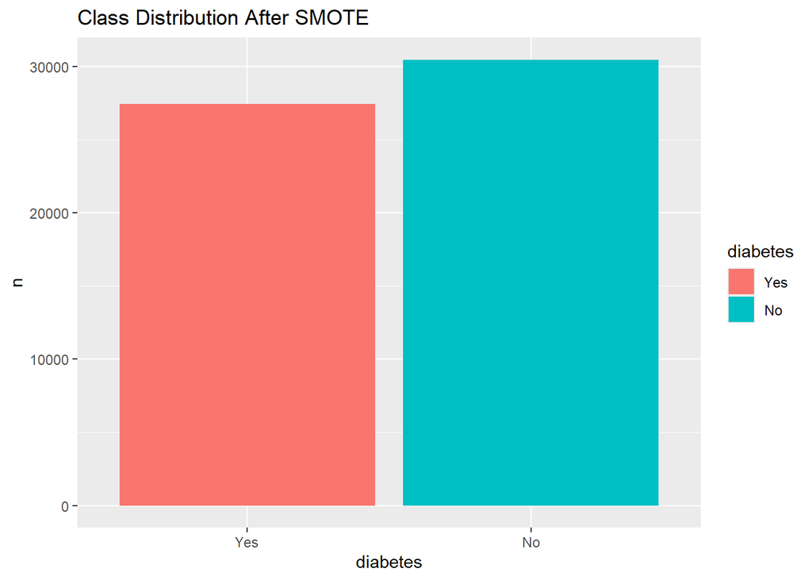

```r
train_data_smote <- rf_recipe_default %>%
  prep() %>%
  bake(new_data = NULL) #This code applies a pre-processing recipe (rf_recipe_default) to the training data. It first prepares the recipe using prep(), which estimates any required parameters (e.g., scaling, encoding, SMOTE), and then applies the transformations using bake(). Setting new_data = NULL means the transformations are applied to the training data itself.


train_data_smote %>%
  count(diabetes) %>%
  ggplot(aes(x = diabetes, y = n, fill = diabetes)) +
  geom_col() +
  ggtitle("Class Distribution After SMOTE") #This code visualizes the class distribution of the diabetes variable after applying SMOTE. It counts the number of observations in each class and uses a bar plot to show how many "Yes" and "No" cases are now present in train_data_smote.
```

### Building workflow

```r
rf_workflow_default <- workflow() %>%
  add_recipe(rf_recipe_default) %>%
  add_model(rf_model_default) #This code creates a modeling workflow object named rf_workflow_default using the workflow() function from the workflows package. It adds two components: rf_recipe_default for pre-processing, and rf_model_default for the Random Forest classification model.

rf_workflow_default
```

```
## ══ Workflow ════════════════════════════════════════════════════════════════════
## Preprocessor: Recipe
## Model: rand_forest()
##
## ── Preprocessor ────────────────────────────────────────────────────────────────
## 2 Recipe Steps
##
## • step_smotenc()
## • step_zv()
##
## ── Model ───────────────────────────────────────────────────────────────────────
## Random Forest Model Specification (classification)
##
## Engine-Specific Arguments:
##   num.threads = cores
##
## Computational engine: ranger
```

### Training the model

```r
rf_workflow_default_fit <- rf_workflow_default %>%
  fit(train_data) #This line fits the rf_workflow_default workflow to the train_data. It applies the preprocessing steps defined in the recipe and then trains the Random Forest model using the ranger engine on the processed data.
```

### Predicting Test Data

#### Class Prediction

```r
rf_predict_default <- predict(rf_workflow_default_fit, new_data = test_data, type = "class") #This line generates predictions from the trained Random Forest model (rf_workflow_default_fit) on the unseen test_data. The type = "class" argument specifies that the predicted output should be class labels (e.g., "Yes" or "No"), rather than probabilities.

rf_predict_default %>%
  head()
```

```
## # A tibble: 6 × 1
##   .pred_class
##   <fct>
## 1 No
## 2 No
## 3 No
## 4 No
## 5 No
## 6 No
```

This is to predict the class of the test_data using the trained model. This is good to assess metrics such as accuracy, precision etc.

#### Probability prediction

```r
rf_default_roc <- predict(rf_workflow_default_fit, new_data = test_data, type = "prob") %>%
  bind_cols(test_data) #This code generates class probability predictions from the fitted Random Forest model using type = "prob" and binds these probabilities to the original test_data using bind_cols(). The result, rf_default_roc, combines model outputs with actual labels for further evaluation (e.g., ROC curve, AUC).

rf_default_roc %>%
  select(.pred_No,.pred_Yes,diabetes) %>%
  glimpse() #This code selects the predicted probabilities for each class (.pred_No, .pred_Yes) and the actual diabetes labels from the rf_default_roc dataset.
```

```
## Rows: 8,238
## Columns: 3
## $ .pred_No  <dbl> 0.8924254, 0.8877230, 0.8653135, 0.6547513, 0.6928283, 0.926…
## $ .pred_Yes <dbl> 0.10757460, 0.11227698, 0.13468651, 0.34524870, 0.30717174, …
## $ diabetes  <fct> No, No, No, No, No, No, No, No, No, No, Yes, No, No, No, No,…
```

The probability predictions gives in probability(out of 1), how likely a prediction is to be No or Yes. This predictions will be used for the ROC_CURVE later in the code

### Combining test data and predictions

```r
rf_predict_default <- rf_predict_default %>%
  cbind(test_data)   # This code is to add the predictions to the test_data. One can use bind_cols to achieve the same results

rf_predict_default <- rf_predict_default %>%
  select(.pred_class,diabetes) # Selecting only the variables I need for the model evaluation

rf_predict_default %>%
  glimpse()
```

```
## Rows: 8,238
## Columns: 2
## $ .pred_class <fct> No, No, No, No, No, No, No, No, No, No, No, No, Yes, No, N…
## $ diabetes    <fct> No, No, No, No, No, No, No, No, No, No, Yes, No, No, No, N…
```

### Model Evaluation

#### Calculating metrics

```r
c_matrix <- conf_mat(rf_predict_default, truth = diabetes, estimate = .pred_class) #This line compute the confusion matrix using the conf_mat() function. It compares the predicted class labels (.pred_class) against the true labels (diabetes) in rf_predict_default.

c_matrix
```

```
##           Truth
## Prediction  Yes   No
##        Yes   62  149
##        No   557 7470
```

The model predicts “No” well (high true negatives: 7470), but frequently misclassifies actual “Yes” cases, leading to many false negatives (557).

```r
metrics <- metric_set(accuracy, sens, spec, precision)  #This code defines a set of evaluation metrics—accuracy, sensitivity (recall), specificity, and precision—using metric_set().

met_default <- metrics(rf_predict_default, truth = diabetes, estimate = .pred_class) #It then computes these metrics by comparing predicted labels (.pred_class) to the actual labels (diabetes) using the metrics() function.

met_default
```

```
## # A tibble: 4 × 3
##   .metric   .estimator .estimate
##   <chr>     <chr>          <dbl>
## 1 accuracy  binary         0.914
## 2 sens      binary         0.100
## 3 spec      binary         0.980
## 4 precision binary         0.294
```

# **Correcting low sensitivity**

From the model above, we can see, sensitivity is 10% whereas specificity is close to 100%.

## Reeducing threshold

```r
rf_default_prob <- rf_default_roc %>%
  select(.pred_No,.pred_Yes,diabetes) %>%
  mutate(pred_class = ifelse(.pred_Yes > 0.23, "Yes", "No")) %>%
  mutate(pred_class = as.factor(pred_class)) %>%
  mutate(pred_class = factor(pred_class,
                             level = c("Yes", "No"))) #

rf_default_prob %>%
  head()
```

```
## # A tibble: 6 × 4
##   .pred_No .pred_Yes diabetes pred_class
##      <dbl>     <dbl> <fct>    <fct>
## 1    0.892    0.108  No       No
## 2    0.888    0.112  No       No
## 3    0.865    0.135  No       No
## 4    0.655    0.345  No       Yes
## 5    0.693    0.307  No       Yes
## 6    0.926    0.0738 No       No
```

This output shows predicted probabilities (.pred_No, .pred_Yes) and predicted class (pred_class). The model sometimes incorrectly predicts “Yes” despite moderate probabilities favoring “No”.

## Evaluating model

```r
con_matrix <- conf_mat(rf_default_prob, truth = diabetes, estimate = pred_class) #This code computes a confusion matrix using the manually thresholded predictions (pred_class) from rf_default_prob, comparing them against the actual diabetes labels.

con_matrix
```

```
##           Truth
## Prediction  Yes   No
##        Yes  371 1818
##        No   248 5801
```

## Defining Metrics_Sets

Here I will decide on metrics to evaluate the model. The metrics used in the analysis are; Accuracy, sensitivity, specificity and precision. Accuracy measures overall correctness; sensitivity detects actual positives; specificity identifies actual negatives; precision evaluates correctness of positive predictions. They can be calculated from the confusion metrics but in this code, I will be using the metric_set function.

```r
metrics <- metric_set(accuracy,sens,spec, precision) #This code defines a set of evaluation metrics—accuracy, sensitivity (recall), specificity, and precision—using metric_set().


metrics_default <- metrics(rf_default_prob, truth = diabetes,estimate =  pred_class) #It then computes these metrics by comparing predicted labels (.pred_class) to the actual labels (diabetes) using the metrics() function.


metrics_default
```

```
## # A tibble: 4 × 3
##   .metric   .estimator .estimate
##   <chr>     <chr>          <dbl>
## 1 accuracy  binary         0.749
## 2 sens      binary         0.599
## 3 spec      binary         0.761
## 4 precision binary         0.169
```

The model has decent overall accuracy (75%), moderate sensitivity (60%) for detecting diabetes, good specificity (ability to detect non-diabetes), but very low precision. The model is performing better(kinda).

### Roc_Curve for default

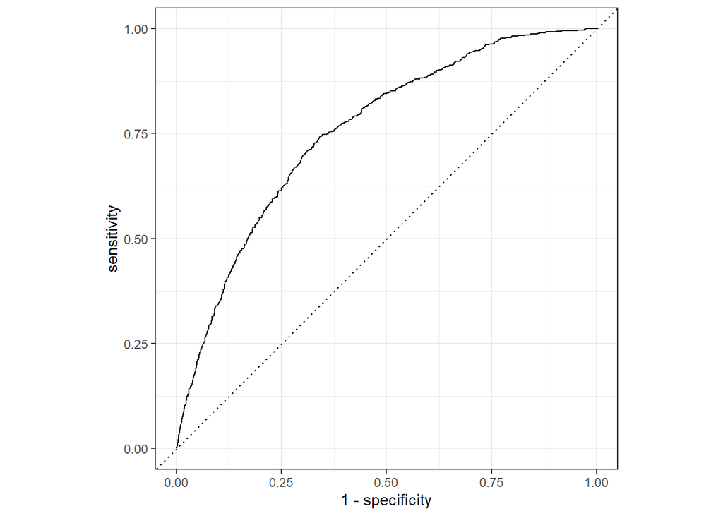

```r
roc_curves_default  <- rf_default_roc %>%
  mutate(diabetes = as.factor(diabetes)) %>%
  roc_curve(truth = diabetes, .pred_Yes) %>%
  autoplot()

roc_curves_default
```

## **Random forest model (Hyperparameters tunning)**

### Building Tuned RF model

```r
rf_model <- rand_forest(mtry = tune(), min_n = tune(), trees = tune()) %>%
              set_engine("ranger", num.threads = cores) %>%
              set_mode("classification") # This code defines a tunable Random Forest classification model with mtry, min_n, and trees as hyperparameters to be optimized. It uses the ranger engine for efficient training with parallel processing enabled via all available CPU cores. The model is set for classification tasks, such as predicting diabetes presence.
```

Here the hyperparameters are tuned to see the best value for each parameter that can give us the best predictions

### Building the Recipe

```r
rf_recipe <-
  recipe(diabetes ~ ., data = train_data) %>%
  step_smotenc(diabetes,over_ratio = 0.50) %>%
  step_zv(all_predictors()) # This code creates a preprocessing recipe for modeling diabetes. It applies SMOTE for class balancing with an over-sampling ratio of 0.50 and removes predictors with zero variance. This prepares the data for more effective and stable Random Forest training.
```

### Building a workflow

```r
rf_workflow <- workflow() %>%
  add_model(rf_model) %>%
  add_recipe(rf_recipe)
  # This code sets up a modeling workflow by combining the tunable Random Forest model and the preprocessing recipe. It ensures that data transformation and model training occur consistently within a single pipeline. This structure simplifies hyperparameter tuning and model evaluation.

rf_workflow
```

```
## ══ Workflow ════════════════════════════════════════════════════════════════════
## Preprocessor: Recipe
## Model: rand_forest()
##
## ── Preprocessor ────────────────────────────────────────────────────────────────
## 2 Recipe Steps
##
## • step_smotenc()
## • step_zv()
##
## ── Model ───────────────────────────────────────────────────────────────────────
## Random Forest Model Specification (classification)
##
## Main Arguments:
##   mtry = tune()
##   trees = tune()
##   min_n = tune()
##
## Engine-Specific Arguments:
##   num.threads = cores
##
## Computational engine: ranger
```

### Hyperparameter tunning

```r
set.seed(100)

folds <- vfold_cv(train_data, v = 10)


rf_tune <- tune_grid(
                rf_workflow,
                resamples = folds,
                control = control_resamples(save_pred = TRUE,
                                                  verbose = FALSE))
```

```
## i Creating pre-processing data to finalize unknown parameter: mtry
```

```r
rf_tune
```

```
## # Tuning results
## # 10-fold cross-validation
## # A tibble: 10 × 5
##    splits               id     .metrics          .notes           .predictions
##    <list>               <chr>  <list>            <list>           <list>
##  1 <split [29654/3295]> Fold01 <tibble [30 × 7]> <tibble [0 × 3]> <tibble>
##  2 <split [29654/3295]> Fold02 <tibble [30 × 7]> <tibble [0 × 3]> <tibble>
##  3 <split [29654/3295]> Fold03 <tibble [30 × 7]> <tibble [0 × 3]> <tibble>
##  4 <split [29654/3295]> Fold04 <tibble [30 × 7]> <tibble [0 × 3]> <tibble>
##  5 <split [29654/3295]> Fold05 <tibble [30 × 7]> <tibble [0 × 3]> <tibble>
##  6 <split [29654/3295]> Fold06 <tibble [30 × 7]> <tibble [0 × 3]> <tibble>
##  7 <split [29654/3295]> Fold07 <tibble [30 × 7]> <tibble [0 × 3]> <tibble>
##  8 <split [29654/3295]> Fold08 <tibble [30 × 7]> <tibble [0 × 3]> <tibble>
##  9 <split [29654/3295]> Fold09 <tibble [30 × 7]> <tibble [0 × 3]> <tibble>
## 10 <split [29655/3294]> Fold10 <tibble [30 × 7]> <tibble [0 × 3]> <tibble>
```

### Evaluating Tunning metrics

```r
tune_metrics <- rf_tune %>%
  collect_metrics() #This code collects performance metrics from the tuning results stored in rf_tune. The resulting tune_metrics includes evaluation scores (e.g., accuracy, ROC AUC) for each combination of hyperparameters tried during tuning. It is used to identify the best-performing model settings.

tune_metrics %>%
  head() # Displaying the first 6 rows of the tune metrics
```

```
## # A tibble: 6 × 9
##    mtry trees min_n .metric     .estimator   mean     n  std_err .config
##   <int> <int> <int> <chr>       <chr>       <dbl> <int>    <dbl> <chr>
## 1    30  1380    37 accuracy    binary     0.908     10 0.00161  Preprocessor1_…
## 2    30  1380    37 brier_class binary     0.0810    10 0.000834 Preprocessor1_…
## 3    30  1380    37 roc_auc     binary     0.773     10 0.00362  Preprocessor1_…
## 4    76  1040    20 accuracy    binary     0.909     10 0.00181  Preprocessor1_…
## 5    76  1040    20 brier_class binary     0.0794    10 0.000713 Preprocessor1_…
## 6    76  1040    20 roc_auc     binary     0.768     10 0.00279  Preprocessor1_…
```

#### Filtering only accuracy

The best hyperparameter values will be based on levels of accuracy.

```r
tune_metrics <- tune_metrics %>%
  filter(.metric == "accuracy") # Filtering accuracy to make it easy to compare hyperparameter values.

tune_metrics %>%
  head()
```

```
## # A tibble: 6 × 9
##    mtry trees min_n .metric  .estimator  mean     n std_err .config
##   <int> <int> <int> <chr>    <chr>      <dbl> <int>   <dbl> <chr>
## 1    30  1380    37 accuracy binary     0.908    10 0.00161 Preprocessor1_Model…
## 2    76  1040    20 accuracy binary     0.909    10 0.00181 Preprocessor1_Model…
## 3    60  1460    16 accuracy binary     0.910    10 0.00144 Preprocessor1_Model…
## 4    65   516     4 accuracy binary     0.912    10 0.00145 Preprocessor1_Model…
## 5     8  1840    21 accuracy binary     0.917    10 0.00142 Preprocessor1_Model…
## 6    46   871     6 accuracy binary     0.914    10 0.00161 Preprocessor1_Model…
```

We are only interested in mean,min_n, trees and mtry

#### Selecting relevant variables

```r
tune_long <- tune_metrics %>%
  select(mean, min_n, trees, mtry) %>%
  pivot_longer(min_n:mtry,
    values_to = "value",
    names_to = "parameter"
  ) #This code reshapes the tuning metrics into a long format for visualization. It selects the mean performance and hyperparameters (min_n, trees, mtry), then uses pivot_longer() to convert the hyperparameter columns into key-value pairs. This format is useful for comparing the effect of each parameter on model performance.

tune_long %>%
  head()
```

```
## # A tibble: 6 × 3
##    mean parameter value
##   <dbl> <chr>     <int>
## 1 0.908 min_n        37
## 2 0.908 trees      1380
## 3 0.908 mtry         30
## 4 0.909 min_n        20
## 5 0.909 trees      1040
## 6 0.909 mtry         76
```

### Visualizing Tuned hyperparameters

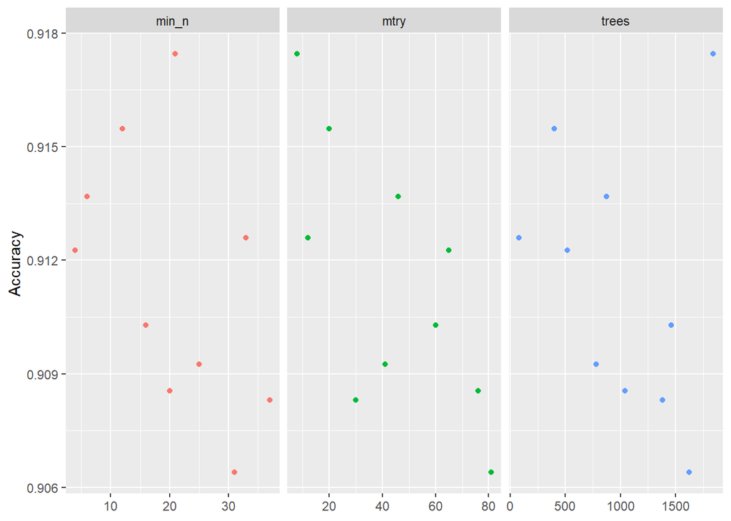

```r
ggplot( tune_long, aes(value, mean, color = parameter)) +
  geom_point(show.legend = FALSE) +
  facet_wrap(~parameter, scales = "free_x") +
  labs(x = NULL, y = "Accuracy") #This code creates a faceted scatter plot to visualize how each hyperparameter (mtry, min_n, trees) influences model accuracy. Each facet displays the relationship between one parameter and the model's mean accuracy, helping identify which settings yield the best performance. The plot aids in selecting optimal tuning values.
```

From the plot, the best tuned model will have mtry between one and 15, min_n of around 21 and trees of 1800

### Selecting best tuned model

```r
rf_best <-
  rf_tune %>%
  select_best(metric = "accuracy") # Filtering accuracy to make it easy to compare hyperparameter values

rf_best  # we know the best model has 1 mtry and 50 min_n
```

```
## # A tibble: 1 × 4
##    mtry trees min_n .config
##   <int> <int> <int> <chr>
## 1     8  1840    21 Preprocessor1_Model05
```

The best model is preprocessor1_model05 because it has the best hyperparameters values as seen on the plot. mtry 8,trees = 1840 and min_n of 21.

### Finalizing the best model

```r
final_rf_model <- finalize_model(rf_model, rf_best) #This code finalizes the Random Forest model by applying the best hyperparameters (rf_best) found during tuning. The resulting final_rf_model is ready for training on the full dataset or for evaluation, using the optimal configuration for performance.
```

### Creating final workflow

```r
rf_workflow_final <- workflow() %>%
  add_model(final_rf_model) %>%
  add_recipe(rf_recipe) #This code builds the final modeling workflow by combining the tuned Random Forest model (final_rf_model) with the preprocessing recipe (rf_recipe). It ensures consistent data preparation and model application using the best hyperparameter settings for final training and evaluation.
```

### Training the final Model

```r
rf_workflow_final_fit <- rf_workflow_final %>%
  fit(train_data) #This code fits the finalized workflow to the training data. It applies all preprocessing steps and trains the tuned Random Forest model on train_data, producing a fully trained model ready for prediction and final evaluation.

rf_workflow_final_fit
```

```
## ══ Workflow [trained] ══════════════════════════════════════════════════════════
## Preprocessor: Recipe
## Model: rand_forest()
##
## ── Preprocessor ────────────────────────────────────────────────────────────────
## 2 Recipe Steps
##
## • step_smotenc()
## • step_zv()
##
## ── Model ───────────────────────────────────────────────────────────────────────
## Ranger result
##
## Call:
##  ranger::ranger(x = maybe_data_frame(x), y = y, mtry = min_cols(~8L,      x), num.trees = ~1840L, min.node.size = min_rows(~21L, x),      num.threads = ~cores, verbose = FALSE, seed = sample.int(10^5,          1), probability = TRUE)
##
## Type:                             Probability estimation
## Number of trees:                  1840
## Sample size:                      45681
## Number of independent variables:  90
## Mtry:                             8
## Target node size:                 21
## Variable importance mode:         none
## Splitrule:                        gini
## OOB prediction error (Brier s.):  0.07486721
```

### Prediciting test data

#### Class Prediction

```r
final_model_predict <- predict(rf_workflow_final_fit,new_data = test_data) %>%
  bind_cols(test_data) #This code makes class predictions on the test_data using the finalized Random Forest model and then binds these predictions with the original test set. The result, final_model_predict, contains both the predicted and actual diabetes labels, enabling evaluation of model accuracy, sensitivity, and other metrics.

final_model_predict<- final_model_predict  %>%
  select(.pred_class, diabetes) #This code refines the final_model_predict dataframe to keep only two columns: the predicted class labels (.pred_class) and the actual labels (diabetes). This streamlined format is ideal for computing evaluation metrics like accuracy, confusion matrix, sensitivity, and specificity.

final_model_predict %>%
  glimpse()
```

```
## Rows: 8,238
## Columns: 2
## $ .pred_class <fct> No, No, No, No, No, No, No, No, No, No, No, No, Yes, No, N…
## $ diabetes    <fct> No, No, No, No, No, No, No, No, No, No, Yes, No, No, No, N…
```

#### Probabiltiy prediciton

```r
rf_tuned_roc <- predict(rf_workflow_final_fit , new_data = test_data, type = "prob") %>%
  bind_cols(test_data) #This code generates predicted class probabilities from the finalized Random Forest model for the test_data, specifying type = "prob". These probabilities are then combined with the original test data, resulting in rf_tuned_roc, which is ready for ROC curve plotting and AUC evaluation.

rf_tuned_roc %>%
  glimpse()
```

```
## Rows: 8,238
## Columns: 93
## $ .pred_Yes                 <dbl> 0.12519133, 0.15828858, 0.14972071, 0.356421…
## $ .pred_No                  <dbl> 0.8748087, 0.8417114, 0.8502793, 0.6435788, …
## $ SDC_GENDER                <fct> 2, 2, 2, 1, 1, 2, 1, 1, 2, 2, 1, 2, 1, 1, 1,…
## $ SDC_AGE_CALC              <dbl> 40, 65, 53, 56, 60, 53, 69, 49, 45, 49, 69, …
## $ SDC_MARITAL_STATUS        <fct> 1, 1, 1, 1, 1, 1, 1, 1, 2, 1, 1, 1, 1, 1, 1,…
## $ SDC_EDU_LEVEL             <fct> 4, 4, 6, 2, 6, 7, 2, 5, 4, 4, 2, 4, 4, 6, 5,…
## $ SDC_EDU_LEVEL_AGE         <dbl> 20, 18, 23, 17, 41, 37, 16, 34, 22, 20, 15, …
## $ SDC_INCOME                <fct> 4, 3, 6, 5, 5, 6, 3, 6, 4, 6, 3, 4, 6, 5, 3,…
## $ SDC_INCOME_IND_NB         <fct> 4, 2, 3, 2, 2, 2, 2, 3, 3, 2, 2, 5, 2, 2, 2,…
## $ SDC_HOUSEHOLD_ADULTS_NB   <fct> 2, 3, 3, 2, 2, 1, 2, 2, 1, 2, 2, 2, 2, 2, 2,…
## $ SDC_HOUSEHOLD_CHILDREN_NB <fct> 2, 0, 0, 0, 0, 0, 0, 1, 2, 0, 0, 3, 0, 0, 0,…
## $ HS_GEN_HEALTH             <fct> 5, 4, 5, 2, 3, 5, 5, 4, 4, 4, 3, 3, 2, 4, 4,…
## $ PA_TOTAL_SHORT            <dbl> 7774.8, 2026.5, 3487.5, 4815.0, 1464.0, 7266…
```

[output cut: 80 more lines]

### Metrics on Tuned Models

#### Confusion Matrix

```r
conf_mat(final_model_predict, truth = diabetes,
         estimate = .pred_class) #This code computes the confusion matrix by comparing the predicted diabetes classes (.pred_class) to the actual labels (diabetes) in final_model_predict. The output shows how many cases were correctly or incorrectly classified, providing insight into model performance across true positives, true negatives, false positives, and false negatives.
```

```
##           Truth
## Prediction  Yes   No
##        Yes   51  109
##        No   568 7510
```

#### Accuracy, Sens, Specs and Precision

```r
metrics <- metric_set(accuracy, sens, spec, precision)
metrics_tune <- metrics(final_model_predict, truth = diabetes,
         estimate = .pred_class)  #This code defines a set of evaluation metrics—accuracy, sensitivity, specificity, and precision—and calculates them using the predicted and actual diabetes labels in final_model_predict. The resulting metrics_tune provides a concise performance summary of the finalized Random Forest model on unseen data.
```

```r
metrics_tune
```

```
## # A tibble: 4 × 3
##   .metric   .estimator .estimate
##   <chr>     <chr>          <dbl>
## 1 accuracy  binary        0.918
## 2 sens      binary        0.0824
## 3 spec      binary        0.986
## 4 precision binary        0.319
```

The model has very high accuracy and specificity, but extremely low sensitivity and poor precision, indicating it fails to detect positives.

### Variable Importance

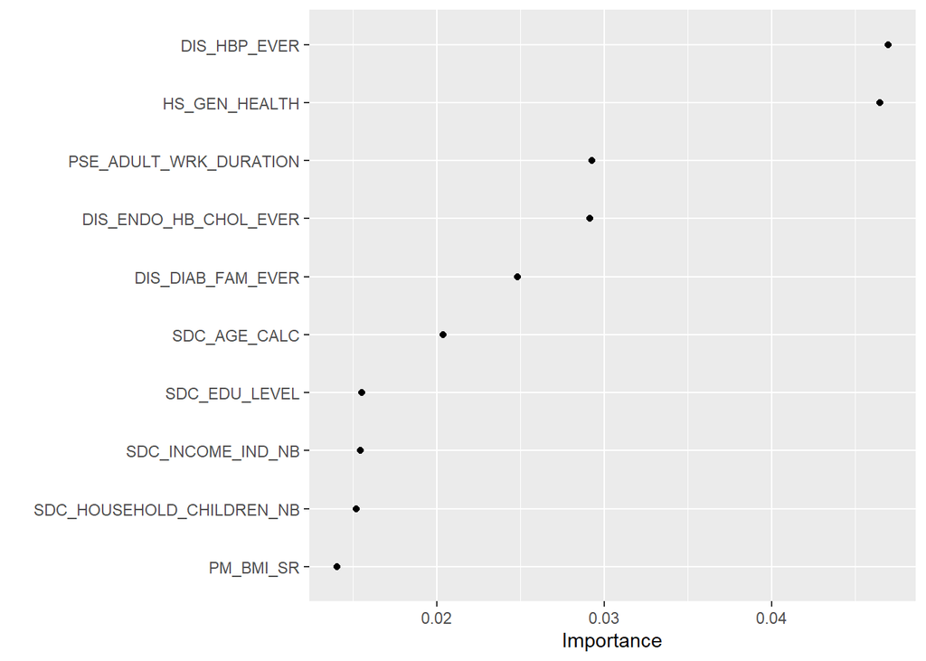

```r
tree_prep <- prep(rf_recipe)

final_rf_model %>%
  set_engine("ranger", importance = "permutation") %>%
  fit(diabetes ~ .,
    data = juice(tree_prep)) %>%
  vip(geom = "point")  #This code fits the final Random Forest model using permutation-based variable importance on the preprocessed training data. It extracts the most influential predictors for diabetes classification. The vip plot visually ranks these variables based on their contribution to model performance.
```

### Roc Curve for tuned

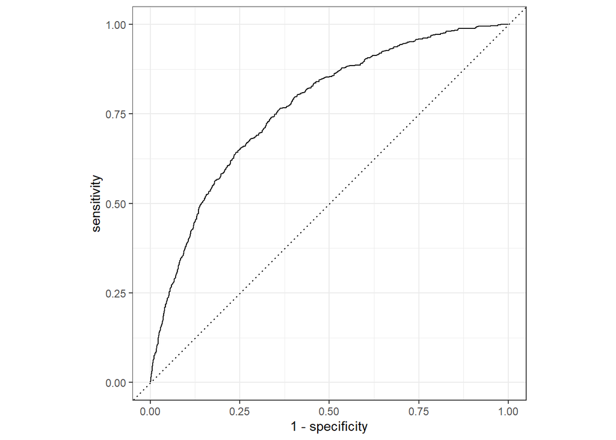

```r
roc_curves_tuned  <- rf_tuned_roc %>%
  yardstick::roc_curve(truth = diabetes, .pred_Yes) %>%
  autoplot()  #This code generates and plots the ROC curve for the tuned Random Forest model using the predicted probabilities of the "Yes" class. It evaluates how well the model distinguishes between diabetes and non-diabetes cases across thresholds. The resulting plot visually summarizes the model’s classification performance.

roc_curves_tuned
```

The ROC curve reveals that the model classifies considerably between diabetes and no diabetes, outperforming the diagonal line(random guess) but remaining limited. The curve’s location suggests fair but poor prediction performance, implying that the model requires improvement to efficiently detect real diabetes patients with minimal errors.

# **Correcting low sensitivity**

```r
metrics_tune # this is the metrics estimates for the tuned RF model
```

```
## # A tibble: 4 × 3
##   .metric   .estimator .estimate
##   <chr>     <chr>          <dbl>
## 1 accuracy  binary        0.918
## 2 sens      binary        0.0824
## 3 spec      binary        0.986
## 4 precision binary        0.319
```

From the metrics tune above, we could see, sensitivity is extremely low whereas specificity is close to 100%. This means, “Yes” prediction has a lower threshold compared to the default 0.5. The next step is to reduce the threshold

## Reducing threshold

```r
rf_default_prob <- rf_tuned_roc %>%
  select(.pred_No,.pred_Yes,diabetes) %>%
  mutate(pred_class = ifelse(.pred_Yes > 0.30, "Yes", "No")) %>%
  mutate(pred_class = as.factor(pred_class)) %>%
  mutate(pred_class = factor(pred_class,
                             level = c("Yes", "No")))  # Trhis code is to reduce the threshold from 0.5 to prediciting yes if the probabilty is >0.30. this idea to help better classification of true positives.

rf_default_prob %>%
  head()
```

```
## # A tibble: 6 × 4
##   .pred_No .pred_Yes diabetes pred_class
##      <dbl>     <dbl> <fct>    <fct>
## 1    0.875    0.125  No       No
## 2    0.842    0.158  No       No
## 3    0.850    0.150  No       No
## 4    0.644    0.356  No       Yes
## 5    0.687    0.313  No       Yes
## 6    0.913    0.0866 No       No
```

The code above is to reduce the threshold for predicting Yes from 0.5 to 0.30 to see how it affects sensitivity and specificity

## Evaluating model

```r
con_matrix <- conf_mat(rf_default_prob, truth = diabetes, estimate = pred_class) #This code computes the confusion matrix by comparing the predicted diabetes classes (.pred_class) to the actual labels (diabetes) in final_model_predict. The output shows how many cases were correctly or incorrectly classified, providing insight into model performance across true positives, true negatives, false positives, and false negatives.

con_matrix
```

```
##           Truth
## Prediction  Yes   No
##        Yes  282  981
##        No   337 6638
```

The model struggles to detect true positives (low sensitivity) but it is better than when we used threshold at 0.5

```r
metric <- metric_set(accuracy,sens,spec, precision)

metrics_tuned <- metric(rf_default_prob, truth = diabetes,estimate =  pred_class)

metrics_tuned
```

```
## # A tibble: 4 × 3
##   .metric   .estimator .estimate
##   <chr>     <chr>          <dbl>
## 1 accuracy  binary         0.840
## 2 sens      binary         0.456
## 3 spec      binary         0.871
## 4 precision binary         0.223
```

# **Model Comparison**

After applying the metric_set function to the predicted values, I saved the variables as metric_default and metric_tuned for the default and tuned RF model respectively. These variables will be used for the model comparison.

## Using default threshold(0.5)

### Labeling metrics

```r
metric_default <- met_default %>%
  mutate(name = "Rf_Default")  #Adding label to the RF model with default hyperparameters

metric_default %>%
  glimpse()
```

```
## Rows: 4
## Columns: 4
## $ .metric    <chr> "accuracy", "sens", "spec", "precision"
## $ .estimator <chr> "binary", "binary", "binary", "binary"
## $ .estimate  <dbl> 0.9142996, 0.1001616, 0.9804436, 0.2938389
## $ name       <chr> "Rf_Default", "Rf_Default", "Rf_Default", "Rf_Default"
```

```r
metric_tuned <- metrics_tune %>%
  mutate(name = "Rf_Tuned")  #Adding label to the RF model with tuned hyperparameters

metric_tuned %>%
  glimpse()
```

```
## Rows: 4
## Columns: 4
## $ .metric    <chr> "accuracy", "sens", "spec", "precision"
## $ .estimator <chr> "binary", "binary", "binary", "binary"
## $ .estimate  <dbl> 0.91781986, 0.08239095, 0.98569366, 0.31875000
## $ name       <chr> "Rf_Tuned", "Rf_Tuned", "Rf_Tuned", "Rf_Tuned"
```

### Binding metrics

```r
# Because each dataframe has the same variables, I can bind the rows to get a single dataset with metrics for the default and tuned RF model. This will help with visualization

metric_eval <- bind_rows(metric_default, metric_tuned)

metric_eval %>%
  glimpse()
```

```
## Rows: 8
## Columns: 4
## $ .metric    <chr> "accuracy", "sens", "spec", "precision", "accuracy", "sens"…
## $ .estimator <chr> "binary", "binary", "binary", "binary", "binary", "binary",…
## $ .estimate  <dbl> 0.91429959, 0.10016155, 0.98044363, 0.29383886, 0.91781986,…
## $ name       <chr> "Rf_Default", "Rf_Default", "Rf_Default", "Rf_Default", "Rf…
```

## Visualizing metrics comparison

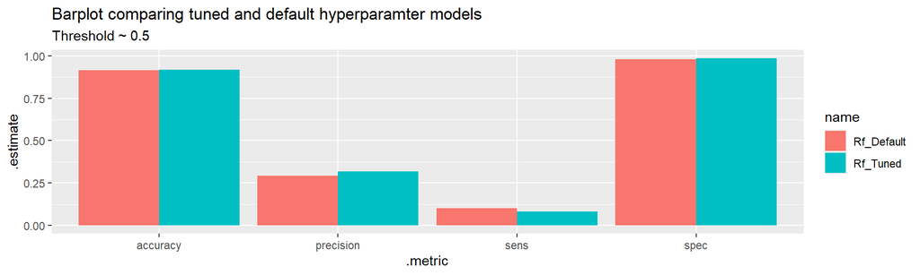

```r
ggplot(data = metric_eval, aes(x = .metric, y = .estimate, fill = name ))+
  geom_col(position = "dodge")+
  labs(title = "Barplot comparing tuned and default hyperparamter models",
       subtitle = "Threshold ~ 0.5")  # This model is to compare the metrics of tuned and default hyperparameter RF model.
```

## Adjusted threshold

### Labeling metrics

```r
metrics_default  # This si the metrics from the default hyperparameter RF model
```

```
## # A tibble: 4 × 3
##   .metric   .estimator .estimate
##   <chr>     <chr>          <dbl>
## 1 accuracy  binary         0.749
## 2 sens      binary         0.599
## 3 spec      binary         0.761
## 4 precision binary         0.169
```

```r
metrics_tuned   #This line of code represents metrics for the tuned RF model
```

```
## # A tibble: 4 × 3
##   .metric   .estimator .estimate
##   <chr>     <chr>          <dbl>
## 1 accuracy  binary         0.840
## 2 sens      binary         0.456
## 3 spec      binary         0.871
## 4 precision binary         0.223
```

### Labeling metrics

```r
metrics_default <- metrics_default %>%
  mutate(name = "Rf_Default")  # This line of code add label or a actegorical variable to help deifferentiate default metrics from the tuned model

metrics_default %>%
  glimpse()
```

```
## Rows: 4
## Columns: 4
## $ .metric    <chr> "accuracy", "sens", "spec", "precision"
## $ .estimator <chr> "binary", "binary", "binary", "binary"
## $ .estimate  <dbl> 0.7492110, 0.5993538, 0.7613860, 0.1694838
## $ name       <chr> "Rf_Default", "Rf_Default", "Rf_Default", "Rf_Default"
```

```r
metrics_tuned <- metrics_tuned %>%
  mutate(name = "Rf_Tuned") # This code adds a label or name to identify tuned metrics in the anlaysis and visualizations

metrics_tuned %>%
  glimpse()
```

```
## Rows: 4
## Columns: 4
## $ .metric    <chr> "accuracy", "sens", "spec", "precision"
## $ .estimator <chr> "binary", "binary", "binary", "binary"
## $ .estimate  <dbl> 0.8400097, 0.4555735, 0.8712429, 0.2232779
## $ name       <chr> "Rf_Tuned", "Rf_Tuned", "Rf_Tuned", "Rf_Tuned"
```

### Binding metrics

```r
metrics_eval <- bind_rows(metrics_default, metrics_tuned)  # This code is to bind the metrics datastes using rows since they have the same variables

metrics_eval %>%
  glimpse()
```

```
## Rows: 8
## Columns: 4
## $ .metric    <chr> "accuracy", "sens", "spec", "precision", "accuracy", "sens"…
## $ .estimator <chr> "binary", "binary", "binary", "binary", "binary", "binary",…
## $ .estimate  <dbl> 0.7492110, 0.5993538, 0.7613860, 0.1694838, 0.8400097, 0.45…
## $ name       <chr> "Rf_Default", "Rf_Default", "Rf_Default", "Rf_Default", "Rf…
```

## Visualizing metrics comparison

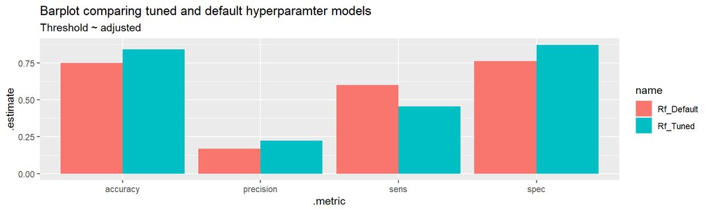

```r
ggplot(data = metrics_eval, aes(x = .metric, y = .estimate, fill = name ))+
  geom_col(position = "dodge")+
  geom_col(position = "dodge")+
  labs(title = "Barplot comparing tuned and default hyperparamter models",
       subtitle = "Threshold ~ adjusted")  # This code generates a plot comparing the metrics of the tuned and default hyperparametrs
```

## **Comparing RoC Curve**

```r
rf_default_roc <- rf_default_roc %>%
  mutate(name = "Rf_Default") #This code adds a new column name to the rf_default_roc dataset, labeling all rows with "Rf_Default". This is useful for comparing multiple models (default vs. tuned) by tagging their outputs for grouped evaluation or combined plotting.

rf_default_prob <- rf_default_prob %>%
  mutate(name = "Rf_Tuned") #This code adds a new column name to the rf_default_roc dataset, labeling all rows with "Rf_Default". This is useful for comparing multiple models (default vs. tuned) by tagging their outputs for grouped evaluation or combined plotting.

eval_roc <- bind_rows(rf_default_prob, rf_default_roc) #This code combines the default probability predictions (rf_default_prob) and the original default ROC data (rf_default_roc) into one dataset called eval_roc.


eval_roc <- eval_roc %>%
  select(name,.pred_No,.pred_Yes,diabetes)  # It then selects only the relevant columns—model name, predicted probabilities, and actual diabetes labels—preparing the data for comparative ROC analysis between model versions.


eval_roc %>%
  glimpse()
```

```
## Rows: 16,476
## Columns: 4
## $ name      <chr> "Rf_Tuned", "Rf_Tuned", "Rf_Tuned", "Rf_Tuned", "Rf_Tuned", …
## $ .pred_No  <dbl> 0.8748087, 0.8417114, 0.8502793, 0.6435788, 0.6865648, 0.913…
## $ .pred_Yes <dbl> 0.12519133, 0.15828858, 0.14972071, 0.35642117, 0.31343516, …
## $ diabetes  <fct> No, No, No, No, No, No, No, No, No, No, Yes, No, No, No, No,…
```

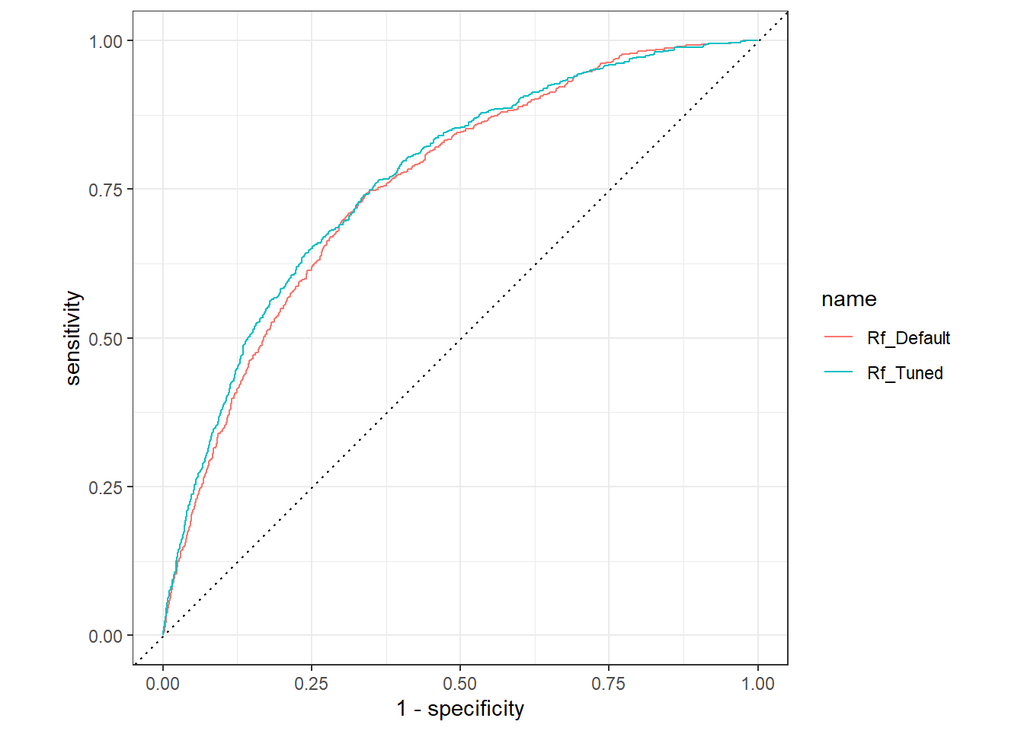

```r
curve <- eval_roc %>%
  group_by(name) %>%
  roc_curve(truth = diabetes, .pred_Yes) %>%
  autoplot() +
  aes(color = name)  #This code plots ROC curves for multiple models grouped by the name column in eval_roc. It shows how each model performs across different thresholds using the true labels and predicted probabilities for the "Yes" class. The resulting plot compares classification performance visually, with each curve colored by model name.

curve
```

From the ROC_CURVE, the area under the curve for the tuned is bigger compared to the default hyperparameter model. This means the tuned model had better overall prediction ability compared to the default model.